```python
import pandas as pd
#load the data
data=pd.read_csv('Data-Week8.csv')
data.head()
```

|  | month | day | FFMC | DMC | DC | ISI | temp | RH | wind |
| --- | --- | --- | --- | --- | --- | --- | --- | --- | --- |
| 0 | 1 | sat | 82.1 | 3.7 | 9.3 | 2.9 | 5.3 | 78 | 3.1 |
| 1 | 1 | sun | 18.7 | 1.1 | 171.4 | 0.0 | 5.2 | 100 | 0.9 |
| 2 | 2 | mon | 84.0 | 9.3 | 34.0 | 2.1 | 13.9 | 40 | 5.4 |
| 3 | 2 | fri | 86.6 | 13.2 | 43.0 | 5.3 | 12.3 | 51 | 0.9 |
| 4 | 2 | thu | 84.2 | 6.8 | 26.6 | 7.7 | 6.7 | 79 | 3.1 |

```python
X=data[[ 'FFMC','DMC','DC','ISI','temp','RH','wind']]
y=data[['month']]
```

```python
from sklearn.model_selection import train_test_split
X_train, X_test, y_train, y_test=train_test_split(X,y,test_size=0.25)
```

```python
from sklearn.tree import DecisionTreeClassifier
from sklearn.metrics import accuracy_score
clf = DecisionTreeClassifier()
clf.fit(X_train,y_train)
```

```
DecisionTreeClassifier()
```

```python
clf.predict(X_test)
#print accuracy
print(accuracy_score(y_true=y_train,y_pred=clf.predict(X_train)))
print(accuracy_score(y_true=y_test,y_pred=clf.predict(X_test)))
```

```
1.0
0.8923076923076924
```

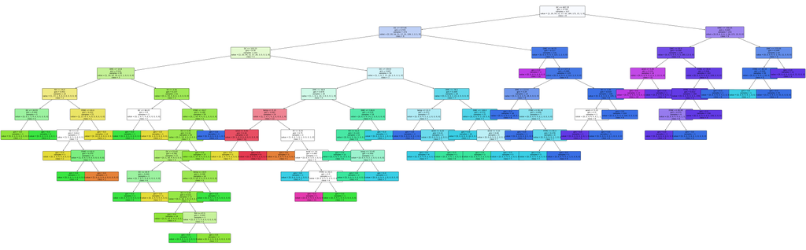

```python
import matplotlib.pyplot as plt
from sklearn.tree import plot_tree

# Drop rows with missing values in any column
data_clean = data.dropna()

# Separate features (X) and target variable (y)
X = data_clean[['FFMC', 'DMC', 'DC', 'ISI', 'temp', 'RH', 'wind']]
y = data_clean['month']
# Create a decision tree classifier and fit the model
M = DecisionTreeClassifier().fit(X, y)

# Set the figure size before calling plot_tree
# Adjust the width and height as needed
plt.figure(figsize=(80,25))

# Use the plot_tree function with adjusted parameters
plot_tree(M, filled=True, fontsize=10, rounded=True, feature_names=X.columns, class_names=y.unique().astype(str))

plt.show()
```

2- Interpret the decision tree based on Gini of each node.

The nodes of decision tree has different Gini values, so if:

Gini Impurity = 0: This means the node is pure; all the training instances at that node belong to the same class. No further splitting is needed, and this node becomes a leaf node in the decision tree.

0 < Gini Impurity < 0.5: Nodes with low Gini impurity indicate relatively pure nodes. The algorithm may use these nodes to make important decisions as they represent subsets of the data where a particular class predominates.

Gini Impurity = 0.5: If a node's Gini impurity is 0.5, it means the algorithm has no information about the data at that node, and further analysis is required to make a meaningful split.

Gini Impurity > 0.5: Nodes with impurity greater than 0.5 are problematic and might indicate issues with the data or the model. Such nodes might be created due to noisy data, insufficient features, or inadequate tree depth.

Gini Impurity = 1: This means the node is maximally impure. It is highly likely that such nodes are split in subsequent iterations of the tree-building algorithm to reduce impurity.

3- Find the month with the highest forest fires? Could you find the reason from Tree?

The month represented by the 7th position in the list has the highest number of forest fires. From the tree we can see that it has a count of 184 samples. This indicates that this specific month had the highest occurrence of forest fires in the dataset used for training the decision tree.